# Parameter Uncertainty in Model-Based Bioequivalence

Plug-in, asymptotic, bootstrap and SIR propagation in virtual parallel BE trials  
**Corrected analysis**

Fixed (Plug-in) VCOV (Asymptotic) Bootstrap SIR

MBBE Uncertainty Analysis **v4 — corrected re-run** • 2026-09-28  
20 batches × 100 trials per cell • 7 sample sizes • 5 T/R ratios • 140 cells • 280,000 trials  
Supersedes v3; the v3 VCOV / Bootstrap / SIR results are withdrawn

## What Changed Since v3

**v3 results for VCOV, Bootstrap and SIR are withdrawn.** They came from a coding error in `sample_from_vcov`: a natural-scale covariance matrix was used as a log-scale covariance. The ≈10–23% “type I error” and the 10–16 pp power loss reported in v3 are artefacts of that error.

| Item | v3 (withdrawn) | v4 (this deck) |
| --- | --- | --- |
| VCOV sampling | MVN(log θ̂, V) with natural-scale V | MVN(log θ̂, D<sup>−1</sup>VD<sup>−1</sup>), D = diag(θ̂) |
| Bootstrap / SIR | MVN from their covariance, same faulty function | Empirical parameter vectors used directly |
| Replicates | VCOV 200 draws; bootstrap 100; SIR 100 resamples | VCOV 1,000; bootstrap 500 refits; SIR 2,000 proposals → 1,000 resamples |
| AUC endpoint | AUC<sub>0–∞</sub> | AUC<sub>0–t</sub> (0–72 h) |
| Sample sizes / arm | 24, 30, 40, 60, 80 | 12, 24, 30, 40, 50, 60, 80 |
| Replication per cell | 200 batches × 200 trials | 20 batches × 100 trials (2,000 trials) |

The Fixed arm never called the faulty function; the v3 Fixed grid is valid but used AUC<sub>0–∞</sub>.

## Outline

1. **Background & Design** — virtual BE, PK model, reference fit, four uncertainty methods, TOST
2. **Results** — power, false acceptance, differences from Fixed, n for 80% power
3. **What Drives the Numbers** — AUC endpoint choice and ratio compression
4. **What Went Wrong in v3** — the scale error, its mechanism, diagnostic re-run
5. **Key Findings, Conclusions & Recommendations**

1

## Background & Design

Virtual BE framework, model and uncertainty methods

## Model-Based Bioequivalence (MBBE)

- A population PK model fitted to existing data is used to simulate *virtual* BE trials
- Used to predict power, choose sample size, and map formulation changes that would still pass
- The parameters driving the simulation are **estimates**, not the truth

**Core question:** does carrying parameter uncertainty into the virtual trials change power or false acceptance — and does the method (asymptotic, bootstrap, SIR) matter?

### Plug-in vs propagated

**Plug-in:** power *conditional* on one parameter vector — “will the trial pass if our estimates are right?”

**Propagated:** expected power over plausible parameter values (assurance) — “how likely is it to pass, given what we know?”

Controlled simulation with a known truth, so every operating characteristic can be checked.

## Virtual BE Trial Design

### Parallel-Group Design

- Two independent arms: **Test** and **Reference**
- Single 100 mg oral dose; hourly sampling 0–72 h
- NCA endpoints: **C<sub>max</sub>** and **AUC<sub>0–t</sub>** (to last observation at 72 h, linear-up/log-down)
- Between-subject %CV under plug-in estimates: AUC<sub>0–t</sub> 22.5%, C<sub>max</sub> 20.9%

True T/R set by the test-product bioavailability F (`tvbio`); the model is linear, so F is the true T/R for both AUC and C<sub>max</sub>.

### Simulation Grid

| Parameter | Values |
| --- | --- |
| Sample sizes (per arm) | 12, 24, 30, 40, 50, 60, 80 |
| True T/R ratios | 0.70, 0.90, 1.00, 1.10, 1.30 |
| Methods | Fixed, VCOV, Bootstrap, SIR |
| Batches per cell | 20 |
| Trials per batch | 100 |
| Trials per cell | 2,000 |
| **Cells / total trials** | **140 / 280,000** |

All 280,000 trials returned a valid result. Every trial is seeded from (method, T/R, n, batch, index), so the grid is exactly reproducible.

## Population PK Model

### Structural Model

Depot' = −Ka · Depot  
Central' = Ka · Depot − (CL/V) · Central  
C<sub>p</sub> = Central / V

### Inter-Individual Variability

CL<sub>i</sub> = tv<sub>CL</sub> · e<sup>η<sub>1</sub></sup>, V<sub>i</sub> = tv<sub>V</sub> · e<sup>η<sub>2</sub></sup>, Ka<sub>i</sub> = tv<sub>Ka</sub> · e<sup>η<sub>3</sub></sup>  
η ~ N(0, Ω), Ω = diag(0.09, 0.09, 0.09)

### True Parameter Values

| Parameter | Value | Description |
| --- | --- | --- |
| tv<sub>CL</sub> | 5.0 L/h | Typical clearance |
| tv<sub>V</sub> | 50.0 L | Typical volume |
| tv<sub>Ka</sub> | 1.2 h<sup>-1</sup> | Absorption rate |
| tv<sub>bio</sub> (F) | = nominal T/R | Test bioavailability (R = 1) |
| ω² | 0.09 | IIV variance (~30% CV) |
| σ | 0.2 mg/L | Residual error (additive) |

`bioav = (Depot = TRT=="T" ? tvbio : 1.0)`  
In every virtual trial `tvbio` is **overwritten** with the scenario's nominal T/R, so parameter uncertainty never shifts the true ratio.

## Reference Study & FOCE Fit

Simulated two-arm parallel reference study, 30 subjects per arm (true F = 1), 73 samples per subject (0–72 h). One fit is shared by every method.

| Parameter | True | Estimate | SE | RSE | 95% CI |
| --- | --- | --- | --- | --- | --- |
| θ<sub>CL</sub> (L/h) | 5.0 | 5.059 | 0.285 | 5.6% | 4.50–5.62 |
| θ<sub>V</sub> (L) | 50.0 | 51.37 | 2.118 | 4.1% | 47.2–55.5 |
| θ<sub>ka</sub> (h<sup>−1</sup>) | 1.2 | 1.165 | 0.077 | 6.6% | 1.01–1.32 |
| F (test/reference) | 1.0 | 0.960 | 0.054 | 5.6% | 0.854–1.066 |
| ω²<sub>CL</sub> | 0.09 | 0.137 | 0.026 | 19.2% | 0.086–0.189 |
| ω²<sub>V</sub> | 0.09 | 0.058 | 0.011 | 19.3% | 0.036–0.080 |
| ω²<sub>ka</sub> | 0.09 | 0.133 | 0.039 | 29.6% | 0.056–0.211 |
| σ (mg/L) | 0.2 | 0.2006 | 0.0023 | 1.1% | 0.196–0.205 |

An informative reference study: fixed-effect RSE 4.1–6.6%, variance components 19–30%, residual SD 1.1%.

## The Four Methods

### 1. Fixed (Plug-in)

The FOCE point estimate θ̂ is used for **every** virtual trial. No uncertainty propagated. Reference baseline.

1 vector: θ̂

### 2. VCOV (Asymptotic)

Draws from a multivariate normal on the **log scale**, with the natural-scale covariance of the estimates transformed by the **delta method**.

1,000 delta-method draws

### 3. Bootstrap

Subjects resampled with replacement, model refitted to each replicate. The refitted parameter vectors are used **directly**. All 500 refits converged.

500 empirical refit vectors

### 4. SIR

Proposals drawn from the asymptotic distribution, weighted by importance ratios and resampled (Dosne et al.). Resampled vectors used **directly**.

2,000 proposals → 1,000 resamples

## How Uncertainty Is Propagated

### VCOV draws: delta-method transform

θ̂ = [tv<sub>CL</sub>, tv<sub>V</sub>, tv<sub>Ka</sub>, tv<sub>bio</sub>, ω²<sub>1</sub>, ω²<sub>2</sub>, ω²<sub>3</sub>, σ]  
Σ̂ = `vcov(fit)` (natural scale)  
D = diag(θ̂)  
Cov(log θ) ≈ D<sup>−1</sup> Σ̂ D<sup>−1</sup>  
log θ<sub>draw</sub> ~ MVN(log θ̂, D<sup>−1</sup> Σ̂ D<sup>−1</sup>)  
θ<sub>draw</sub> = exp(log θ<sub>draw</sub>) (always positive)

Bootstrap and SIR need no transform: their empirical vectors are used as drawn.

### Per-Trial Simulation Flow

Step 1 Draw one vector at random from the method's set

Step 2 Overwrite tvbio with the nominal T/R

Step 3 Simulate n Test + n Reference subjects

Step 4 NCA → AUC<sub>0–t</sub>, C<sub>max</sub>

Step 5 TOST on log-scale values

Result Pass = AUC<sub>0–t</sub> *and* C<sub>max</sub> 90% CI within 80–125%

Uncertainty acts only on CL, V, Ka, Ω and σ (nuisance parameters). Uncertainty in F is deliberately not propagated — it would change the truth being tested.

## Uncertainty Distributions Agree Closely

Median (2.5th–97.5th percentile) of the parameter sets used in the grid

| Parameter | VCOV (1,000 draws) | Bootstrap (500 refits) | SIR (1,000 resamples) |
| --- | --- | --- | --- |
| θ<sub>CL</sub> (L/h) | 5.05 (4.50–5.63) | 5.07 (4.56–5.60) | 5.05 (4.54–5.58) |
| θ<sub>V</sub> (L) | 51.2 (47.5–55.6) | 51.4 (47.7–55.7) | 51.6 (47.6–55.7) |
| θ<sub>ka</sub> (h<sup>−1</sup>) | 1.16 (1.01–1.33) | 1.17 (1.02–1.33) | 1.16 (1.03–1.30) |
| ω²<sub>CL</sub> | 0.138 (0.096–0.199) | 0.135 (0.089–0.189) | 0.143 (0.102–0.193) |
| ω²<sub>V</sub> | 0.058 (0.040–0.083) | 0.056 (0.036–0.078) | 0.060 (0.041–0.083) |
| ω²<sub>ka</sub> | 0.131 (0.074–0.254) | 0.128 (0.052–0.199) | 0.141 (0.078–0.217) |
| σ (mg/L) | 0.201 (0.196–0.205) | 0.201 (0.196–0.205) | 0.200 (0.196–0.205) |

## TOST for Parallel-Design BE

### Two One-Sided Tests

H<sub>0</sub>: μ<sub>T</sub> − μ<sub>R</sub> ≤ log(0.80) *or* ≥ log(1.25)  
H<sub>1</sub>: log(0.80) < μ<sub>T</sub> − μ<sub>R</sub> < log(1.25)  
GMR = exp(Δ), Δ = x̄<sub>T</sub> − x̄<sub>R</sub>  
90% CI = exp(Δ ± t<sub>0.95, df</sub> · SE)

**BE concluded:** 90% CI of the GMR within [0.80, 1.25] for *both* AUC<sub>0–t</sub> and C<sub>max</sub>

### Parallel Design Specifics

- Pooled-variance two-sample t-test on log values
- SE = √(s<sub>p</sub>² · (1/n<sub>R</sub> + 1/n<sub>T</sub>))
- df = 2n − 2

### Operating Characteristics

- **Power**: P(conclude BE) at T/R 0.90, 1.00, 1.10
- **False acceptance**: P(conclude BE) at T/R 0.70, 1.30 (outside the limits)
- Mean over 20 batches; 95% CI from the batch SE
- n for 80% power at T/R 1.00: linear interpolation between adjacent n

2

## Results

Corrected re-run: 140 cells, 2,000 trials each

## Power at T/R = 1.00 (True Equivalence)

Power (%), mean (95% CI) over 20 batches × 100 trials

Fixed VCOV Bootstrap SIR

| n/arm | Fixed | VCOV | Bootstrap | SIR |
| --- | --- | --- | --- | --- |
| 12 | 38.8 (36.9–40.8) | 36.5 (34.5–38.5) | 42.0 (39.4–44.5) | 35.6 (33.2–37.9) |
| 24 | 89.6 (88.3–90.8) | 88.0 (86.5–89.4) | 90.0 (88.6–91.5) | 87.8 (86.2–89.4) |
| 30 | 96.2 (95.5–96.9) | 94.8 (94.2–95.4) | 96.6 (96.0–97.2) | 94.5 (93.8–95.2) |
| 40 | 99.5 (99.2–99.8) | 99.0 (98.5–99.4) | 99.0 (98.6–99.4) | 99.3 (98.9–99.7) |
| 50 | 99.9 (99.8–100.0) | 99.6 (99.4–99.8) | 99.8 (99.6–100.0) | 100.0 (99.9–100.0) |
| 60 | 100.0 (100.0–100.0) | 100.0 (99.9–100.0) | 100.0 (100.0–100.0) | 99.9 (99.8–100.0) |
| 80 | 100.0 (100.0–100.0) | 100.0 (100.0–100.0) | 100.0 (100.0–100.0) | 100.0 (100.0–100.0) |

All four methods track each other. VCOV and SIR sit 2.4 and 3.3 pp below Fixed at n = 12; Bootstrap sits 3.1 pp above (95% CI −0.1 to +6.3). From n = 40 upward no method differs from Fixed by more than 0.55 pp.

## Power vs Sample Size (Figure 1)

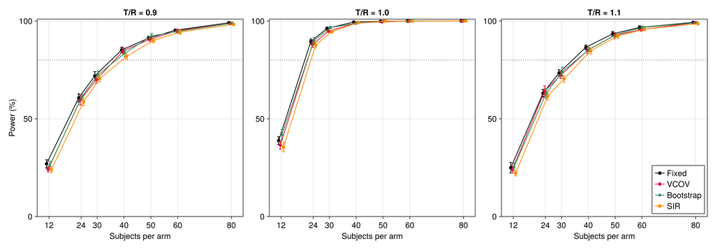

Means over 20 batches of 100 trials; bars are 95% CIs; methods offset slightly on the x-axis; dotted line = 80%. In the figure Fixed is plotted in **black**, VCOV crimson, Bootstrap green, SIR orange.

## Power Near the Limits: T/R = 0.90 and 1.10

Power (%), mean (95% CI)

### T/R = 0.90

| n/arm | Fixed | VCOV | Boot | SIR |
| --- | --- | --- | --- | --- |
| 12 | 27.0 (24.9–29.0) | 24.2 (22.9–25.4) | 26.2 (24.1–28.3) | 23.9 (22.5–25.3) |
| 24 | 60.7 (58.6–62.8) | 59.6 (57.0–62.3) | 61.2 (59.9–62.6) | 58.7 (56.7–60.7) |
| 30 | 72.0 (69.8–74.1) | 70.0 (68.1–72.0) | 72.5 (70.6–74.4) | 70.6 (68.9–72.3) |
| 40 | 85.2 (83.7–86.7) | 84.7 (83.1–86.3) | 83.6 (81.8–85.4) | 81.8 (80.4–83.2) |
| 50 | 91.2 (90.2–92.2) | 90.7 (89.5–91.9) | 92.4 (91.2–93.6) | 90.0 (88.9–91.1) |
| 60 | 95.3 (94.8–95.8) | 95.0 (94.1–95.9) | 94.8 (93.7–95.8) | 94.4 (93.2–95.5) |
| 80 | 99.1 (98.6–99.6) | 98.8 (98.3–99.2) | 98.8 (98.3–99.4) | 98.2 (97.7–98.8) |

### T/R = 1.10

| n/arm | Fixed | VCOV | Boot | SIR |
| --- | --- | --- | --- | --- |
| 12 | 25.0 (22.3–27.6) | 24.0 (22.3–25.7) | 25.4 (23.5–27.3) | 22.2 (20.8–23.5) |
| 24 | 63.0 (61.1–65.0) | 64.2 (61.5–66.8) | 63.1 (60.6–65.6) | 61.8 (59.6–63.9) |
| 30 | 73.5 (72.0–75.0) | 72.3 (70.6–74.0) | 74.0 (71.6–76.4) | 70.4 (68.6–72.2) |
| 40 | 86.6 (85.5–87.7) | 85.0 (83.4–86.5) | 85.5 (84.5–86.5) | 84.8 (83.2–86.3) |
| 50 | 93.4 (92.3–94.6) | 92.6 (91.1–94.1) | 93.0 (92.1–94.0) | 92.3 (91.2–93.4) |
| 60 | 96.7 (95.8–97.6) | 95.6 (94.8–96.4) | 96.8 (96.2–97.3) | 95.8 (95.0–96.6) |
| 80 | 99.3 (98.8–99.8) | 99.1 (98.6–99.6) | 99.2 (98.8–99.5) | 98.6 (98.0–99.3) |

Same pattern as T/R 1.00, with somewhat larger differences persisting to n = 40. Largest single difference from Fixed: −3.4 pp (SIR, T/R 0.90, n = 40; 95% CI −5.4 to −1.4).

## Sample Size for 80% Power (T/R = 1.00)

Subjects per arm, linear interpolation between n = 12 and n = 24

21.7

Fixed

22.1

VCOV

21.5

Bootstrap

22.2

SIR

### Spread across methods: 0.7 subjects per arm

With an informative reference study, propagating parameter uncertainty changes the planned sample size by less than one subject per arm, whichever method is used.

## False Acceptance at T/R = 0.70 and 1.30

Probability (%) of concluding BE when the product is not equivalent, mean (95% CI)

| n/arm | T/R = 0.70 |  |  |  | T/R = 1.30 |  |  |  |
| --- | --- | --- | --- | --- | --- | --- | --- | --- |
|  | Fixed | VCOV | Boot | SIR | Fixed | VCOV | Boot | SIR |
| 12 | 0.2 (0.0–0.3) | 0.2 (0.0–0.3) | 0.1 (0.0–0.2) | 0.0 (0.0–0.1) | 1.2 (0.6–1.9) | 1.4 (1.0–1.8) | 1.0 (0.6–1.4) | 1.0 (0.6–1.3) |
| 24 | 0.1 (0.0–0.2) | 0.0 (0.0–0.1) | 0.0 (0.0–0.1) | 0.0 (0.0–0.1) | 1.8 (1.3–2.3) | 2.0 (1.4–2.5) | 1.4 (0.9–1.8) | 1.6 (1.1–2.1) |
| 30 | 0.0 (0.0–0.1) | 0.0 (0.0–0.0) | 0.1 (0.0–0.2) | 0.1 (0.0–0.2) | 1.2 (0.8–1.7) | 1.6 (1.0–2.2) | 1.2 (0.8–1.6) | 1.7 (1.1–2.3) |
| 40 | 0.0 (0.0–0.0) | 0.0 (0.0–0.1) | 0.0 (0.0–0.0) | 0.0 (0.0–0.0) | 1.2 (0.6–1.9) | 1.6 (1.0–2.2) | 1.5 (1.0–2.0) | 1.8 (1.2–2.5) |
| 50 | 0.0 (0.0–0.1) | 0.0 (0.0–0.1) | 0.0 (0.0–0.0) | 0.1 (0.0–0.2) | 1.2 (0.7–1.7) | 1.4 (1.0–1.9) | 2.2 (1.6–2.7) | 1.6 (1.1–2.1) |
| 60 | 0.0 (0.0–0.0) | 0.0 (0.0–0.1) | 0.0 (0.0–0.0) | 0.0 (0.0–0.0) | 1.4 (0.9–1.8) | 1.6 (0.9–2.3) | 1.4 (1.0–1.9) | 1.7 (1.1–2.3) |
| 80 | 0.0 (0.0–0.0) | 0.0 (0.0–0.0) | 0.0 (0.0–0.0) | 0.0 (0.0–0.0) | 1.3 (0.7–1.9) | 1.5 (1.0–2.0) | 1.4 (0.9–1.8) | 1.4 (0.9–2.0) |

At most 0.2% at T/R 0.70 and 1.0–2.2% at T/R 1.30 for every method. **No rise with sample size** and no systematic difference between methods — the opposite of the v3 pattern.

## False Acceptance vs Sample Size (Figure 2)

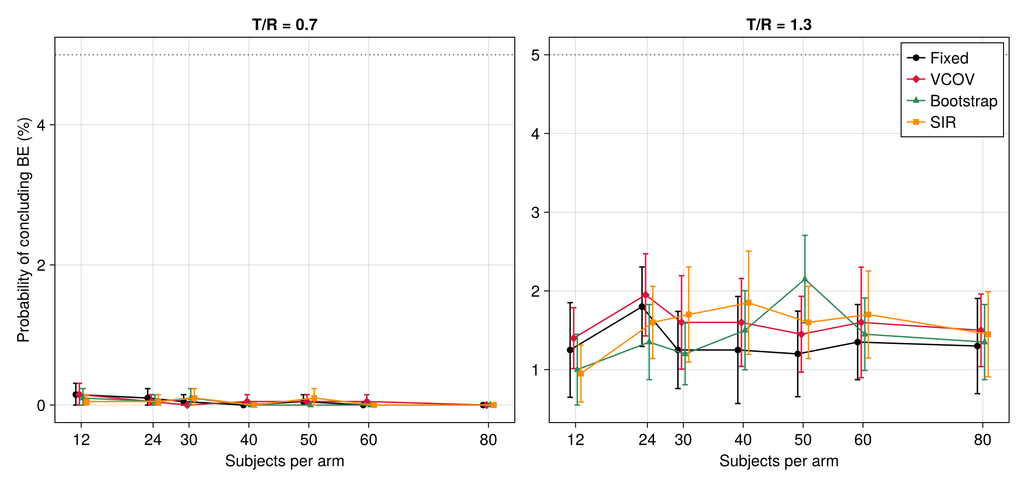

Dotted line = 5%. Note the different vertical scales. Fixed in black. The 1–2% floor at T/R 1.30 is a property of the design (ratio compression, see Section 3), common to all methods.

## Power Difference from Fixed (pp) — T/R = 1.00

Method minus Fixed, percentage points [95% CI], two decimals. Highlighted: CI excludes zero.

| n/arm | Fixed (%) | VCOV Δ | Bootstrap Δ | SIR Δ |
| --- | --- | --- | --- | --- |
| 12 | 38.8 (36.9–40.8) | −2.35 [−5.16, +0.46] | +3.10 [−0.11, +6.31] | −3.30 [−6.36, −0.24] |
| 24 | 89.6 (88.3–90.8) | −1.60 [−3.53, +0.33] | +0.50 [−1.46, +2.46] | −1.75 [−3.79, +0.29] |
| 30 | 96.2 (95.5–96.9) | −1.40 [−2.30, −0.50] | +0.40 [−0.49, +1.29] | −1.70 [−2.68, −0.72] |
| 40 | 99.5 (99.2–99.8) | −0.55 [−1.06, −0.04] | −0.50 [−1.02, +0.02] | −0.20 [−0.66, +0.26] |
| 50 | 99.9 (99.8–100.0) | −0.30 [−0.56, −0.04] | −0.05 [−0.30, +0.20] | +0.05 [−0.12, +0.22] |
| 60 | 100.0 (100.0–100.0) | −0.05 [−0.15, +0.05] | 0.00 [0.00, 0.00] | −0.10 [−0.23, +0.03] |
| 80 | 100.0 (100.0–100.0) | 0.00 [0.00, 0.00] | 0.00 [0.00, 0.00] | 0.00 [0.00, 0.00] |

VCOV and SIR run slightly below Fixed at n ≤ 30 (1.6–1.8 pp at n = 24); Bootstrap within −0.5 to +3.1 pp of Fixed. From n = 40 all differences are ≤ 0.55 pp.

## Power Difference from Fixed (pp) — T/R = 0.90 and 1.10

Method minus Fixed [95% CI]. Highlighted: CI excludes zero.

| n/arm | T/R = 0.90 |  |  | T/R = 1.10 |  |  |
| --- | --- | --- | --- | --- | --- | --- |
|  | VCOV | Boot | SIR | VCOV | Boot | SIR |
| 12 | −2.8 [−5.3, −0.3] | −0.8 [−3.7, +2.2] | −3.1 [−5.6, −0.5] | −0.9 [−4.1, +2.2] | +0.4 [−2.8, +3.7] | −2.8 [−5.8, +0.2] |
| 24 | −1.1 [−4.4, +2.3] | +0.5 [−1.9, +3.0] | −2.0 [−4.8, +0.8] | +1.1 [−2.2, +4.4] | +0.1 [−3.1, +3.2] | −1.3 [−4.2, +1.6] |
| 30 | −1.9 [−4.8, +1.0] | +0.5 [−2.3, +3.4] | −1.4 [−4.1, +1.4] | −1.2 [−3.5, +1.1] | +0.5 [−2.4, +3.4] | −3.1 [−5.5, −0.7] |
| 40 | −0.5 [−2.7, +1.7] | −1.6 [−3.9, +0.7] | −3.4 [−5.4, −1.4] | −1.6 [−3.6, +0.3] | −1.1 [−2.6, +0.4] | −1.8 [−3.8, +0.1] |
| 50 | −0.5 [−2.0, +1.0] | +1.2 [−0.4, +2.8] | −1.2 [−2.7, +0.3] | −0.9 [−2.8, +1.1] | −0.4 [−1.9, +1.1] | −1.2 [−2.8, +0.5] |
| 60 | −0.3 [−1.4, +0.8] | −0.5 [−1.7, +0.6] | −1.0 [−2.2, +0.3] | −1.1 [−2.3, +0.1] | 0.0 [−1.0, +1.1] | −0.9 [−2.1, +0.3] |
| 80 | −0.3 [−1.0, +0.3] | −0.3 [−1.0, +0.5] | −0.8 [−1.6, −0.1] | −0.2 [−0.9, +0.5] | −0.1 [−0.7, +0.4] | −0.6 [−1.4, +0.1] |

## False-Acceptance Difference from Fixed (pp)

Method minus Fixed [95% CI], two decimals (one trial in 2,000 = 0.05 pp). Highlighted: CI excludes zero.

| n/arm | T/R = 0.70 |  |  | T/R = 1.30 |  |  |
| --- | --- | --- | --- | --- | --- | --- |
|  | VCOV | Boot | SIR | VCOV | Boot | SIR |
| 12 | 0.00 [−0.23, +0.23] | −0.05 [−0.26, +0.16] | −0.10 [−0.29, +0.09] | +0.15 [−0.56, +0.86] | −0.25 [−1.00, +0.50] | −0.30 [−1.00, +0.40] |
| 24 | −0.05 [−0.22, +0.12] | −0.05 [−0.22, +0.12] | −0.05 [−0.22, +0.12] | +0.15 [−0.58, +0.88] | −0.45 [−1.14, +0.24] | −0.20 [−0.88, +0.48] |
| 30 | −0.05 [−0.15, +0.05] | +0.05 [−0.12, +0.22] | +0.05 [−0.12, +0.22] | +0.35 [−0.42, +1.12] | −0.05 [−0.68, +0.58] | +0.45 [−0.33, +1.23] |
| 40 | +0.05 [−0.05, +0.15] | 0.00 [0.00, 0.00] | 0.00 [0.00, 0.00] | +0.35 [−0.53, +1.23] | +0.25 [−0.60, +1.10] | +0.60 [−0.34, +1.54] |
| 50 | 0.00 [−0.14, +0.14] | −0.05 [−0.15, +0.05] | +0.05 [−0.12, +0.22] | +0.25 [−0.48, +0.98] | +0.95 [+0.17, +1.73] | +0.40 [−0.31, +1.11] |
| 60 | +0.05 [−0.05, +0.15] | 0.00 [0.00, 0.00] | 0.00 [0.00, 0.00] | +0.25 [−0.60, +1.10] | +0.10 [−0.56, +0.76] | +0.35 [−0.38, +1.08] |
| 80 | 0.00 [0.00, 0.00] | 0.00 [0.00, 0.00] | 0.00 [0.00, 0.00] | +0.20 [−0.56, +0.96] | +0.05 [−0.72, +0.82] | +0.15 [−0.66, +0.96] |

41 of 42 comparisons include zero; the exception (Bootstrap, T/R 1.30, n = 50: +0.95 [+0.17, +1.73]) is isolated and consistent with chance across 42 comparisons.

## Comparison Summary

≤ 3.4 pp

largest power difference from Fixed  
(SIR, T/R 0.90, n = 40)

53 / 63

power comparisons whose  
95% CI includes zero

≤ 1.2 pp

largest power difference  
at n ≥ 50

21.5–22.2

n/arm for 80% power  
(all four methods)

- **Direction follows the variance components.** Averaging over uncertain ω² weights high-variability draws, which cost more power than low-variability draws gain → VCOV and SIR slightly below Fixed at small n.
- **SIR** gave the lowest power in 17 of 21 within-limit cells (including one four-way tie at 100%).
- **Bootstrap** put less weight on large variance components (see the distributions slide), so its power sat at or slightly above Fixed at T/R 1.00.
- Monte Carlo SE is about one point near 50% power, so differences below ~2 pp cannot be resolved.

3

## What Drives the Numbers

AUC endpoint choice and ratio compression under additive error

## The AUC Endpoint Mattered More Than the Method

Fixed power (%) at T/R = 1.00. The Fixed arm of v3 differs from v4 only in the AUC endpoint and random streams.

| n/arm | AUC<sub>0–∞</sub> (v3 grid, 40,000 trials/cell) | AUC<sub>0–t</sub> (v4 grid, 2,000 trials/cell) |
| --- | --- | --- |
| 24 | 60.5 | 89.6 |
| 30 | 76.2 | 96.2 |
| 40 | 90.1 | 99.5 |
| 60 | 98.5 | 100.0 |
| 80 | 99.8 | 100.0 |
| n for 80% | ≈ 32.7 | 21.7 |

**Why:** the terminal phase falls below the residual SD (0.2 mg/L) within 72 h, so the extrapolation slope is fitted largely to noise. This inflates the variability of AUC<sub>0–∞</sub> and compresses its ratio towards 1 (median AUC<sub>0–∞</sub> ratio 0.80–0.82 at a true 0.70, even for plausible V).

### Endpoint effect > 10× the method effect

Switching AUC<sub>0–∞</sub> → AUC<sub>0–t</sub> moved n for 80% power from ≈ 33 to 22 per arm; the four uncertainty methods differ by 0.7.

n for 80% with AUC<sub>0–∞</sub>: linear interpolation of the v3 Fixed grid (76.2% at n = 30, 90.1% at n = 40), the same rule as for AUC<sub>0–t</sub>.

## Additive Error Compresses Observed Ratios Towards 1

Fixed, AUC<sub>0–t</sub>; 200 trials per cell. Observed GMR: median (5th–95th percentile). Pass rates in %.

| True T/R | n/arm | C<sub>max</sub> GMR | AUC<sub>0–t</sub> GMR | C<sub>max</sub> pass | AUC<sub>0–t</sub> pass | Both pass |
| --- | --- | --- | --- | --- | --- | --- |
| 0.70 | 24 | 0.745 (0.669–0.815) | 0.799 (0.732–0.875) | 0.0 | 4.5 | 0.0 |
| 0.70 | 80 | 0.738 (0.704–0.778) | 0.793 (0.753–0.839) | 0.0 | 3.0 | 0.0 |
| 1.30 | 24 | 1.260 (1.154–1.373) | 1.211 (1.076–1.347) | 2.5 | 12.0 | 0.5 |
| 1.30 | 80 | 1.261 (1.204–1.324) | 1.202 (1.138–1.289) | 1.0 | 26.5 | 0.5 |

Every concentration carries noise common to both arms, pulling ratios towards 1 — AUC<sub>0–t</sub> more than C<sub>max</sub>, because it integrates the low late concentrations. At a true 1.30 the median AUC<sub>0–t</sub> ratio (1.20–1.21) lies **inside** the limits.

On AUC<sub>0–t</sub> alone, 12% (n = 24) and 27% (n = 80) would pass at T/R 1.30. Overall false acceptance stays near 1% only because C<sub>max</sub> (effective ratio just above 1.25) is co-primary; it tends to a small constant, not zero.

4

## What Went Wrong in v3

The covariance scale error, its mechanism and the diagnostic re-run

## The Bug: Natural-Scale Covariance Used as Log-Scale

### v3 `sample_from_vcov` (schematic)

V = vcov(fit) # natural scale (Pumas)  
dist = MvNormal(log.(θ̂), V) # treated as log scale  
θ = exp.(rand(dist))

### v4 (corrected)

D⁻¹ = Diagonal(1 ./ θ̂)  
dist = MvNormal(log.(θ̂), D⁻¹ V D⁻¹) # delta method  
θ = exp.(rand(dist))

Bootstrap and SIR arms in v3 were also drawn through this function (from the covariance of the bootstrap / SIR results), so all three propagation arms were affected — which is why they looked alike.

### What it did to V

- SE(θ<sub>V</sub>) = 2.12 L on an estimate of 51.4 L (RSE 4.1%)
- Correct log-scale SD ≈ 2.12 / 51.4 ≈ 0.04
- Used as-is on the log scale: log-SD = **2.1**
- Drawn V spanned **0.96–2,120 L** (95% range) instead of 47.5–55.0 L

Parameters with small natural-scale variances (Ω, σ) went the other way: drawn with almost **no** uncertainty.

## Parameter Draws: Original vs Corrected Transform

VCOV draws (200 each): 2.5th / 50th / 97.5th percentiles

| Parameter | Estimate (SE) | Original (v3) | Corrected (delta method) |
| --- | --- | --- | --- |
| θ<sub>CL</sub> (L/h) | 5.06 (0.29) | 2.96 / 5.00 / 7.78 | 4.52 / 5.04 / 5.56 |
| θ<sub>V</sub> (L) | 51.4 (2.1) | **0.96 / 39.3 / 2,120** | 47.5 / 51.6 / 55.0 |
| θ<sub>ka</sub> (h<sup>−1</sup>) | 1.17 (0.08) | 1.01 / 1.16 / 1.32 | 1.01 / 1.16 / 1.33 |
| ω²<sub>V</sub> | 0.058 (0.011) | **0.057 / 0.058 / 0.059** | 0.040 / 0.059 / 0.088 |
| σ (mg/L) | 0.201 (0.002) | 0.200 / 0.201 / 0.201 | 0.196 / 0.200 / 0.205 |

V drawn over three orders of magnitude, while ω²<sub>V</sub> and σ were effectively fixed. Neither is a representation of the estimation uncertainty.

## Mechanism: the Additive-Error Floor (Figure 3)

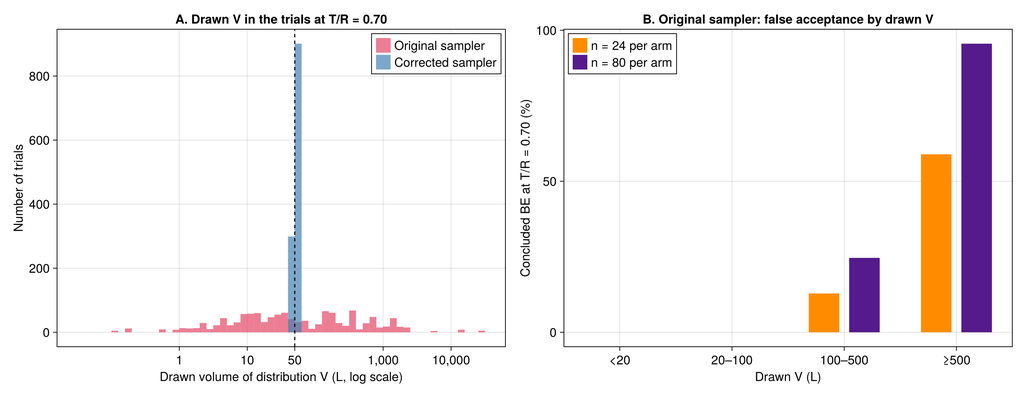

(A) Drawn V in the diagnostic trials at T/R 0.70, original vs corrected sampler (dashed line at 50 L). (B) Original sampler: % concluding BE at T/R 0.70 by drawn V.

| Drawn V (L) | n = 24 |  |  | n = 80 |  |  |
| --- | --- | --- | --- | --- | --- | --- |
|  | Trials | BE % | Med C<sub>max</sub> ratio | Trials | BE % | Med C<sub>max</sub> ratio |
| < 20 | 199 | 0.0 | 0.707 | 238 | 0.0 | 0.704 |
| 20–100 | 149 | 0.0 | 0.726 | 134 | 0.0 | 0.733 |
| 100–500 | 140 | 12.9 | 0.873 | 138 | 24.6 | 0.857 |
| ≥ 500 | 112 | 58.9 | 0.956 | 90 | 95.6 | 0.959 |

V ≈ 2,000 L → peak concentration ≈ 0.04 mg/L, far below σ = 0.2 mg/L. Observed values (truncated at zero) are noise common to both arms, NCA ratios collapse towards 1, and TOST passes whatever the true F.

**Larger n detects this artefactual equivalence more reliably** → false acceptance rose with n.

## Diagnostic Re-run: As-Run vs Corrected

Probability (%) of concluding BE; 600 trials per cell; same fitted model (refit with the original seed reproduces θ̂); AUC<sub>0–∞</sub> as in v3

| T/R | n/arm | Fixed | VCOV as-run (v3) | VCOV corrected |
| --- | --- | --- | --- | --- |
| 0.70 | 24 | 0.0 | 14.0 | 0.17 |
| 0.70 | 80 | 0.0 | 20.0 | 0.0 |
| 1.00 | 24 | 61.5 | 44.3 | 61.3 |
| 1.00 | 80 | 99.7 | 98.3 | 99.7 |
| 1.30 | 24 | 0.5 | 12.3 | 0.33 |
| 1.30 | 80 | 0.5 | 24.7 | 1.17 |

The correction alone removes the false acceptance and restores power to the Fixed level. On the stored v3 grid (200 × 200 trials per cell) the faulty implementation had given ≈10–23% false acceptance across VCOV, Bootstrap and SIR, rising with n in every case.

## v3 Claims That Are Withdrawn

“Uncertainty methods inflate type I error to 10–22%, worsening with n” → artefact of the scale error; corrected: ≤ 0.2% (T/R 0.70), 1.0–2.2% (T/R 1.30), no trend in n.

“Fixed overestimates power by 10–16 pp” → corrected differences ≤ 3.4 pp, only at n ≤ 40.

“Add 30–50% more subjects than Fixed suggests” → n for 80% power 21.5–22.2 per arm under every method.

“The paradox explained: parameter draws shift tvbio towards 1” / “uncertainty leak” → tvbio is overwritten with the nominal T/R in every trial; this mechanism never operated.

“Bootstrap is the best-performing method”; method ranking → methods are within Monte Carlo error of each other in most cells.

“MBBE uncertainty propagation does not maintain nominal α; adjust BE limits” → correctly implemented propagation does not raise false acceptance.

5

## Key Findings & Conclusions

## Key Findings

### 1. Method choice has little effect with an informative reference study

Power differs from Fixed by at most 3.4 pp, only at 12–40 subjects per arm (≤ 1.2 pp from n = 50); n for 80% power 21.5–22.2 per arm for all four methods.

### 2. Correct propagation does not inflate false acceptance

≤ 0.2% at T/R 0.70 and 1.0–2.2% at 1.30, flat in n. Propagation acts only on nuisance parameters; TOST controls its size at each of their values.

### 3. Implementation and endpoint choices dominate

A wrongly scaled covariance produced up to ~25% false acceptance; AUC<sub>0–∞</sub> under a noise-dominated terminal phase raised n for 80% power from ~22 to ~33 per arm.

### 4. A rising false-acceptance rate is a diagnostic of failure

At ratios outside the limits, a pass rate that rises with n signals broken propagation or a model producing data in which T/R can no longer be measured.

## Conclusions

1. **Propagation changes the question** from “will the trial pass if our estimates are right?” to “how likely is it to pass, given what we know?”
2. **With an informative reference study, asymptotic, bootstrap and SIR give very similar answers** to each other and to the plug-in approach, and none inflates false acceptance at non-equivalent ratios.
3. **Implementation choices matter far more.** A covariance sampled on the wrong scale gave up to ~25% false acceptance; an AUC endpoint dominated by residual error inflated the planned sample size by about half (33 vs 22 per arm).
4. **The pass rate at ratios outside the limits, and its trend with n,** is a simple and effective check on any uncertainty-propagation pipeline.

## Recommendations

### Implementing propagation

- Reconcile scales: delta-method transform of the natural-scale covariance, or parameterise on the log scale throughout
- Use bootstrap / SIR parameter vectors directly, not an MVN built from their covariance
- Compare sampled distributions with the estimates and SEs *before* running any trials
- Methods that should differ but look identical are a warning sign

### Reporting & design

- Report the pass rate at ratios outside the limits alongside power, across n
- Treat the endpoint definition as a modelling decision; where extrapolated AUC is needed, check the residual-error model and sampling window against a realistic LLOQ
- Expect method differences when the reference study is small or sparse, variance components are poorly estimated, or the model is strongly nonlinear

## Limitations & Technical Details

### Limitations

- Simple model: one compartment, linear, single dose, additive error
- Informative reference study (60 subjects × 73 samples) favours the asymptotic approximation
- Parallel design only; crossover / replicate designs may behave differently
- Parameter uncertainty only, not model-structure uncertainty
- 2,000 trials/cell: differences below ~2 pp cannot be resolved
- Additive error compresses ratios; low false acceptance at 1.30 depends on C<sub>max</sub> being co-primary. A proportional/combined error model would be more realistic
- Natural extensions: less informative reference study, NTI limits

### Implementation

| Component | Detail |
| --- | --- |
| Language / modelling | Julia 1.11.8, Pumas (FOCE) |
| NCA / BE testing | Pumas NCA; pooled-variance TOST |
| Scripts | `rerun/01–05_*.jl` |
| Grid | 4 methods × 7 n × 5 T/R |
| Replication | 20 × 100 trials per cell |
| **Total** | **140 cells, 280,000 trials** |
| Diagnostic re-run | 600 trials/cell, AUC<sub>0–∞</sub> |

# Thank You

Questions & Discussion

Fixed VCOV Bootstrap SIR

MBBE Uncertainty Analysis v4 — corrected re-run, 2026-09-28  
Pumas + Julia

MBBE Uncertainty v4 (corrected, 2026-09-28) — Parameter Uncertainty in Virtual BE